# 102.3. Table joins with TAP

For the Rubin Science Platform at data.lsst.cloud.  
Data Release: [Data Preview 1](https://dp1.lsst.io)  
Container Size: large  
LSST Science Pipelines version: r29.2.0  
Last verified to run: 2025-09-02  
Repository: github.com/lsst/tutorial-notebooks

**Learning objective:** How to join tables in TAP queries on catalogs.

**LSST data products:** `ForcedSourceOnDiaObject`, `Visit`, `DiaSource`, `SSSource` tables

**Packages:** `lsst.rsp.get_tap_service`

**Credit:** Originally developed by the Rubin Community Science team. Please consider acknowledging them if this notebook is used for the preparation of journal articles, software releases, or other notebooks.

**Get Support:** Everyone is encouraged to ask questions or raise issues in the [Support Category](https://community.lsst.org/c/support) of the Rubin Community Forum. Rubin staff will respond to all questions posted there.

## 1. Introduction

TAP provides standardized access to catalog data for discovery, search, and retrieval. Full [documentation for TAP](http://www.ivoa.net/documents/TAP) is provided by the International Virtual Observatory Alliance (IVOA).

ADQL (Astronomy Data Query Language) is similar to SQL (Structured Query Langage). The [documentation for ADQL](http://www.ivoa.net/documents/latest/ADQL.html) includes more information about syntax and keywords. Not all ADQL functionality is supported yet in the preview-era RSP.

### 1.1. Table joins

Tables can be joined when they have an index or identifier column in common.

There are four main types of table joins in ADQL/SQL:

- inner: will return rows that appear in both tables and meet constraints (intersection set)
- outer: will return rows from either table that meet constraints (union set)
- left: will return rows from the first table that meet constraints, plus matching rows from the second table
- right: will return rows from the second table that meet constraints, plus matching rows from the first table

When `JOIN` is used in an ADQL query, it is an inner join by default.

**Generic example:** To include a table join in an ADQL query requires the specification of which column to be "joined on". For example, the query below retrieves all rows from "table1" that are within 0.002 degrees of coordinates ra_cen, dec_cen, but only if there is a row in "table2" which has the same value of `id` (i.e., an inner join, which is default). Columns `mag` and `band` from "table2" are also returned for these matching rows.

```
SELECT t1.id, t1.ra, t1.dec, t2.mag, t2.band
FROM catalog.table1 AS t1
JOIN catalog.table2 AS t2 ON t1.id = t2.id
WHERE CONTAINS(POINT('IRCS', t1.ra, t1.dec), CIRCLE('ICRS', ra_cen, dec_cen, 0.002)) = 1
```

**Related tutorials**: The other 100-level tutorials in this series demonstrate the TAP basics. The 200-level tutorials for the individual catalogs list which tables are joinable with them.

### 1.2. Import packages

Import general python packages `numpy`, `matplotlib`, the RSP TAP service, and LSST utility functions for plotting.

```python
import numpy as np
import matplotlib.pyplot as plt
from lsst.rsp import get_tap_service
from lsst.utils.plotting import (get_multiband_plot_colors,
                                 get_multiband_plot_symbols)
```

### 1.3. Define parameters

Instantiate the TAP service.

```python
service = get_tap_service("tap")
assert service is not None
```

Define filter names, plot markers, and colors for plotting.

```python
filter_names = ['u', 'g', 'r', 'i', 'z', 'y']
filter_colors = get_multiband_plot_colors()
filter_symbols = get_multiband_plot_symbols()
```

## 2. Use case: light curves

Light curves are an object's brightness over time.

The tables of forced photometry measurements in all individual `visit_images` and `difference_images`, which should be used for LSST light curves, are:

- `ForcedSource`: at the locations of all `Objects`
- `ForcedSourceOnDiaObject`: at the locations of all `DiaObjects`

They both need to be joined with the `Visit` table on the shared column of the visit identifier (`visit` or `visitId`) to obtain the time (MJD) of the observation, and plot the light curve.

### 2.1. Example: join Visit with ForcedSourceOnDiaObject

For a known variable star that was detected with difference image analysis (DIA) and has a `diaObjectId` of 614435753623027782, join the `ForcedSourceOnDiaObject` table with the `Visit` table.

Retrieve the `band` (filter) and `psfFlux` (direct-image forced PSF photometry) for every visit from the `ForcedSourceOnDiaObject`.

Join to the `Visit` table on the visit identifier to retrieve each visit's Modified Julian Date, so that flux vs. time can be plotted (i.e., the light curve).

```python
query = """SELECT fsodo.band, fsodo.psfFlux, vis.expMidptMJD
        FROM dp1.ForcedSourceOnDiaObject as fsodo
        JOIN dp1.Visit as vis
        ON vis.visit = fsodo.visit
        WHERE fsodo.diaObjectId = 614435753623027782"""
print(query)
```

```
SELECT fsodo.band, fsodo.psfFlux, vis.expMidptMJD
        FROM dp1.ForcedSourceOnDiaObject as fsodo
        JOIN dp1.Visit as vis
        ON vis.visit = fsodo.visit
        WHERE fsodo.diaObjectId = 614435753623027782
```

```python
job = service.submit_job(query)
job.run()
job.wait(phases=['COMPLETED', 'ERROR'])
print('Job phase is', job.phase)
if job.phase == 'ERROR':
    job.raise_if_error()
assert job.phase == 'COMPLETED'
results = job.fetch_result().to_table()
print(len(results))
```

```
Job phase is COMPLETED
225
```

```python
results.colnames
```

```
['band', 'psfFlux', 'expMidptMJD']
```

Plot the light curve.

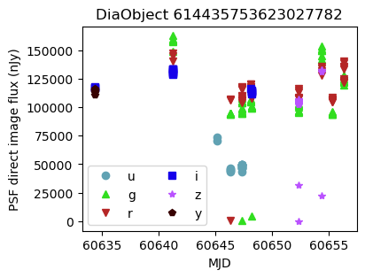

```python
fig = plt.figure(figsize=(4, 3))
for filt in filter_names:
    fx = np.where(results['band'] == filt)[0]
    plt.plot(results['expMidptMJD'][fx],
             results['psfFlux'][fx], filter_symbols[filt],
             color=filter_colors[filt], label=filt)
plt.xlabel('MJD')
plt.ylabel('PSF direct image flux (nJy)')
plt.legend(ncols=2)
plt.title('DiaObject 614435753623027782')
plt.show()
```

> Figure 1: A light curve created via table join.

## 3. Use case: moving objects

All of the Solar System catalogs are joinable to each other on identifiers `diaSourceId` (individual detections in the difference images), `ssObjectId` (associations of detections into single moving objects).

### 3.1. Example: join SSSource and DiaSource

Use the `ssObjectId` of a known moving object, 21163620217073748, and retrieve the heliocentric X and Y coordinates at the times of the individual observations from the `SSSource` table. Join to the `DiaSource` table to retrieve the MJD times of the individual observations. Sort the results by MJD.

```python
query = """SELECT sss.heliocentricX, sss.heliocentricY,
        dias.midpointMjdTai
        FROM dp1.SSSource as sss
        JOIN dp1.DiaSource as dias
        ON dias.diaSourceId = sss.diaSourceId
        WHERE sss.ssObjectId = 21163620217073748
        ORDER BY dias.midpointMjdTai ASC"""
print(query)
```

```
SELECT sss.heliocentricX, sss.heliocentricY,
        dias.midpointMjdTai
        FROM dp1.SSSource as sss
        JOIN dp1.DiaSource as dias
        ON dias.diaSourceId = sss.diaSourceId
        WHERE sss.ssObjectId = 21163620217073748
        ORDER BY dias.midpointMjdTai ASC
```

```python
job = service.submit_job(query)
job.run()
job.wait(phases=['COMPLETED', 'ERROR'])
print('Job phase is', job.phase)
if job.phase == 'ERROR':
    job.raise_if_error()
assert job.phase == 'COMPLETED'
results = job.fetch_result().to_table()
print(len(results))
```

```
Job phase is COMPLETED
133
```

```python
# results
```

Plot the heliocentric X and Y coordinates for the individual observations, and color the points by days since first detection to visualize the orbit.

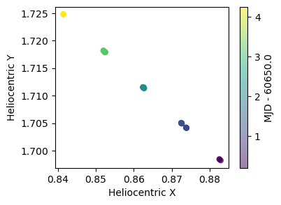

```python
day1 = np.floor(results['midpointMjdTai'][0])
fig = plt.figure(figsize=(4, 3))
plt.scatter(results['heliocentricX'],
            results['heliocentricY'],
            c=results['midpointMjdTai']-day1,
            cmap='viridis', alpha=0.5, edgecolors='none')
plt.xlabel('Heliocentric X')
plt.ylabel('Heliocentric Y')
plt.colorbar(label='MJD - '+str(day1))
plt.show()
```

> Figure 2: A moving object's trajectory created via table join.